# Classification 2

```python
import numpy as np
import pandas as pd
from pandas_profiling import ProfileReport
import matplotlib.pyplot as plt
import seaborn as sns
from sklearn.model_selection import train_test_split, cross_val_score, GridSearchCV, cross_validate, RandomizedSearchCV
from sklearn.metrics import r2_score, accuracy_score, confusion_matrix
from sklearn.linear_model import Lasso
from sklearn.ensemble import RandomForestClassifier, GradientBoostingClassifier
from sklearn.tree import DecisionTreeClassifier
import statistics as stats
```

Source: https://archive.ics.uci.edu/ml/datasets/default+of+credit+card+clients

Data Set Information:

This research aimed at the case of customers default payments in Taiwan.

Attribute Information:

This research employed a binary variable, default payment (Yes = 1, No = 0), as the response variable. This study reviewed the literature and used the following 23 variables as explanatory variables:

X1: Amount of the given credit (NT dollar): it includes both the individual consumer credit and his/her family (supplementary) credit.

X2: Gender (1 = male; 2 = female).

X3: Education (1 = graduate school; 2 = university; 3 = high school; 4 = others).

X4: Marital status (1 = married; 2 = single; 3 = others).

X5: Age (year).

X6 - X11: History of past payment. We tracked the past monthly payment records (from April to September, 2005) as follows: X6 = the repayment status in September, 2005; X7 = the repayment status in August, 2005; . . .;X11 = the repayment status in April, 2005. The measurement scale for the repayment status is: -1 = pay duly; 1 = payment delay for one month; 2 = payment delay for two months; . . .; 8 = payment delay for eight months; 9 = payment delay for nine months and above.

X12-X17: Amount of bill statement (NT dollar). X12 = amount of bill statement in September, 2005; X13 = amount of bill statement in August, 2005; . . .; X17 = amount of bill statement in April, 2005.

X18-X23: Amount of previous payment (NT dollar). X18 = amount paid in September, 2005; X19 = amount paid in August, 2005; . . .;X23 = amount paid in April, 2005.

```python
df = pd.read_excel("default.xls", header = 1)
```

```python
df = df.iloc[:,1:]
```

```python
df
```

|  | LIMIT_BAL | SEX | EDUCATION | MARRIAGE | AGE | PAY_0 | PAY_2 | PAY_3 | PAY_4 | PAY_5 | ... | BILL_AMT4 | BILL_AMT5 | BILL_AMT6 | PAY_AMT1 | PAY_AMT2 | PAY_AMT3 | PAY_AMT4 | PAY_AMT5 | PAY_AMT6 | default payment next month |
| --- | --- | --- | --- | --- | --- | --- | --- | --- | --- | --- | --- | --- | --- | --- | --- | --- | --- | --- | --- | --- | --- |
| 0 | 20000 | 2 | 2 | 1 | 24 | 2 | 2 | -1 | -1 | -2 | ... | 0 | 0 | 0 | 0 | 689 | 0 | 0 | 0 | 0 | 1 |
| 1 | 120000 | 2 | 2 | 2 | 26 | -1 | 2 | 0 | 0 | 0 | ... | 3272 | 3455 | 3261 | 0 | 1000 | 1000 | 1000 | 0 | 2000 | 1 |
| 2 | 90000 | 2 | 2 | 2 | 34 | 0 | 0 | 0 | 0 | 0 | ... | 14331 | 14948 | 15549 | 1518 | 1500 | 1000 | 1000 | 1000 | 5000 | 0 |
| 3 | 50000 | 2 | 2 | 1 | 37 | 0 | 0 | 0 | 0 | 0 | ... | 28314 | 28959 | 29547 | 2000 | 2019 | 1200 | 1100 | 1069 | 1000 | 0 |
| 4 | 50000 | 1 | 2 | 1 | 57 | -1 | 0 | -1 | 0 | 0 | ... | 20940 | 19146 | 19131 | 2000 | 36681 | 10000 | 9000 | 689 | 679 | 0 |
| ... | ... | ... | ... | ... | ... | ... | ... | ... | ... | ... | ... | ... | ... | ... | ... | ... | ... | ... | ... | ... | ... |
| 29995 | 220000 | 1 | 3 | 1 | 39 | 0 | 0 | 0 | 0 | 0 | ... | 88004 | 31237 | 15980 | 8500 | 20000 | 5003 | 3047 | 5000 | 1000 | 0 |
| 29996 | 150000 | 1 | 3 | 2 | 43 | -1 | -1 | -1 | -1 | 0 | ... | 8979 | 5190 | 0 | 1837 | 3526 | 8998 | 129 | 0 | 0 | 0 |
| 29997 | 30000 | 1 | 2 | 2 | 37 | 4 | 3 | 2 | -1 | 0 | ... | 20878 | 20582 | 19357 | 0 | 0 | 22000 | 4200 | 2000 | 3100 | 1 |
| 29998 | 80000 | 1 | 3 | 1 | 41 | 1 | -1 | 0 | 0 | 0 | ... | 52774 | 11855 | 48944 | 85900 | 3409 | 1178 | 1926 | 52964 | 1804 | 1 |
| 29999 | 50000 | 1 | 2 | 1 | 46 | 0 | 0 | 0 | 0 | 0 | ... | 36535 | 32428 | 15313 | 2078 | 1800 | 1430 | 1000 | 1000 | 1000 | 1 |

30000 rows × 24 columns

```python
ProfileReport(df,minimal=True)
```

[interactive chart not shown]

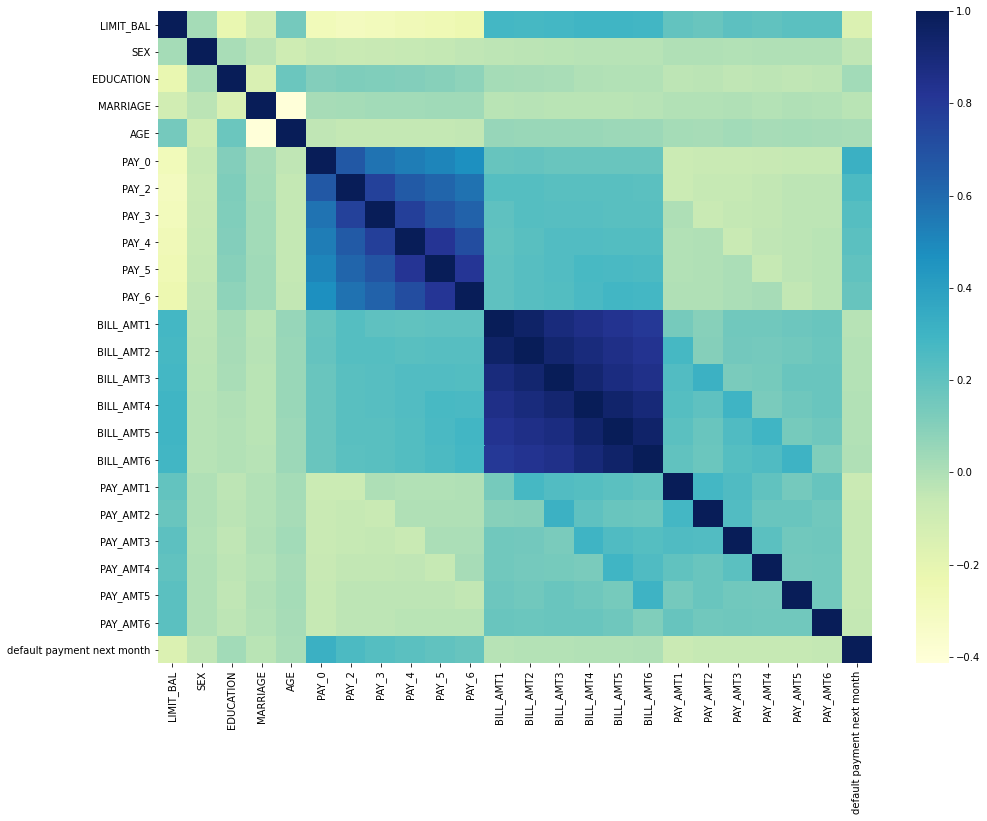

```python
plt.figure(figsize=(16,12))
sns.heatmap(df.corr(),cmap= "YlGnBu")
```

It seems like there are highly correlated columns. But it seems like they are observations from the same category.

```python
y = np.asarray(df["default payment next month"])
X = np.asarray(df.drop("default payment next month",1))
```

```python
X.shape
```

```
(30000, 23)
```

```python
y.shape
```

```
(30000,)
```

```python
X_train, X_test, y_train, y_test = train_test_split(X, y, test_size=0.33, random_state=42)
```

# Lasso

```python
print("Original")
lasso_model_original = Lasso().fit(X_train,y_train)
lasso_prediction_original = lasso_model_original.predict(X_test)
print("Accuracy score: ", accuracy_score(y_test,lasso_prediction_original>lasso_prediction_original.mean()))
```

```
Original
Accuracy score:  0.5131313131313131
```

```python
print("Manual")
lasso_model_manual = Lasso(alpha = 0.01).fit(X_train,y_train)
lasso_prediction_manual = lasso_model_manual.predict(X_test)
print("Accuracy score: ", accuracy_score(y_test,lasso_prediction_original>lasso_prediction_original.mean()))
```

```
Manual
Accuracy score:  0.5131313131313131
```

```python
lasso_grid_search = {'alpha': list(np.linspace(0, 0.01, 6, dtype=float))}

lasso_model_grid = GridSearchCV(estimator=Lasso(), param_grid = lasso_grid_search,
                                     cv=5, n_jobs=-1,return_train_score = True)
lasso_model_grid.fit(X_train, y_train)

print("Grid")
print("Best alpha: ", lasso_model_grid.best_estimator_.alpha)
lasso_prediction_grid = lasso_model_grid.best_estimator_.predict(X_test)
print("Accuracy score: ", accuracy_score(y_test,lasso_prediction_grid>lasso_prediction_grid.mean()))
```

```
Grid
Best alpha:  0.0
Accuracy score:  0.6005050505050505
```

```python
results = pd.DataFrame(lasso_model_grid.cv_results_)
results["mean_train_score"]
```

```
0    0.126742
1    0.126450
2    0.125734
3    0.125193
4    0.124853
5    0.124501
Name: mean_train_score, dtype: float64
```

```python
results["mean_test_score"]
```

```
0    0.123272
1    0.123005
2    0.122345
3    0.121903
4    0.121731
5    0.121498
Name: mean_test_score, dtype: float64
```

These are R2 scores, so let's compare them to the prediction's r2 score

```python
lasso_prediction_grid_r2 = lasso_model_grid.best_estimator_.predict(X_test)
print("R2 score: ", r2_score(y_test,lasso_prediction_grid_r2))
```

```
R2 score:  0.11802012826582531
```

There is not much over or underfitting, but the lasso model isn't accurate at all.

# Decision Tree

```python
print("Original")
dt_model_original = DecisionTreeClassifier().fit(X_train,y_train)
dt_prediction_original = dt_model_original.predict(X_test)
print("Accuracy score: ", accuracy_score(y_test,dt_prediction_original))
```

```
Original
Accuracy score:  0.7294949494949495
```

```python
print("Manual")
dt_model_manual = DecisionTreeClassifier(min_samples_leaf = 2 ,ccp_alpha = 0).fit(X_train,y_train)
dt_prediction_manual = dt_model_manual.predict(X_test)
print("Accuracy score: ", accuracy_score(y_test,dt_prediction_manual))
```

```
Manual
Accuracy score:  0.7433333333333333
```

```python
dt_grid_search = {'min_samples_leaf': list(np.linspace(20, 50, 6, dtype=int)),
                 'ccp_alpha': list(np.linspace(0, 1, 6, dtype=float))}

dt_model_grid = GridSearchCV(estimator=DecisionTreeClassifier(), param_grid = dt_grid_search,
                                     verbose = 5,cv=5, n_jobs=-1,return_train_score = True)
dt_model_grid.fit(X_train, y_train)

print("Grid")
print("Best min_samples_leaf: ", dt_model_grid.best_estimator_.min_samples_leaf)
print("Best ccp_alpha: ", dt_model_grid.best_estimator_.ccp_alpha)
dt_prediction_grid = dt_model_grid.best_estimator_.predict(X_test)
print("Accuracy score: ", accuracy_score(y_test,dt_prediction_grid))
```

```
Fitting 5 folds for each of 36 candidates, totalling 180 fits
```

```
[Parallel(n_jobs=-1)]: Using backend LokyBackend with 8 concurrent workers.
[Parallel(n_jobs=-1)]: Done   2 tasks      | elapsed:    0.5s
[Parallel(n_jobs=-1)]: Done  56 tasks      | elapsed:    4.7s
[Parallel(n_jobs=-1)]: Done 146 tasks      | elapsed:   12.4s
[Parallel(n_jobs=-1)]: Done 180 out of 180 | elapsed:   14.7s finished
```

```
Grid
Best min_samples_leaf:  50
Best ccp_alpha:  0.0
Accuracy score:  0.8145454545454546
```

```python
results = pd.DataFrame(dt_model_grid.cv_results_)
results[results["rank_test_score"]<=5]["mean_train_score"]
```

```
1    0.835759
2    0.832475
3    0.829726
4    0.828234
5    0.827152
Name: mean_train_score, dtype: float64
```

```python
results[results["rank_test_score"]<=5]["mean_test_score"]
```

```
1    0.803234
2    0.808358
3    0.809900
4    0.813284
5    0.814080
Name: mean_test_score, dtype: float64
```

The best "the minimal number of observations per tree leaf" is 50 and best complexity is 0.0. The accuracy score is much better than lasso regression. Maybe it could be improved further with more hyperparameter tuning.

# Random Forest

```python
print("Original")
rf_model_original = RandomForestClassifier().fit(X_train,y_train)
rf_prediction_original = rf_model_original.predict(X_test)
print("Accuracy score: ", accuracy_score(y_test,rf_prediction_original))
```

```
Original
Accuracy score:  0.813939393939394
```

```python
print("Manual")
rf_model_manual = RandomForestClassifier(n_estimators = 500, min_samples_leaf = 5, max_samples = 150).fit(X_train,y_train)
rf_prediction_manual = rf_model_manual.predict(X_test)
print("Accuracy score: ", accuracy_score(y_test,rf_prediction_manual))
```

```
Manual
Accuracy score:  0.8041414141414142
```

```python
rf_grid_search = {'max_samples': list(np.linspace(0, 500, 6, dtype=int))}

rf_model_grid = GridSearchCV(estimator=RandomForestClassifier(n_estimators = 500, min_samples_leaf = 5), param_grid = rf_grid_search,
                                     verbose = 5,cv=5, n_jobs=-1,return_train_score = True)
rf_model_grid.fit(X_train, y_train)

print("Grid")
print("Best max_samples: ", rf_model_grid.best_estimator_.max_samples)
rf_prediction_grid = rf_model_grid.best_estimator_.predict(X_test)
print("Accuracy score: ", accuracy_score(y_test,rf_prediction_grid))
```

```
Fitting 5 folds for each of 6 candidates, totalling 30 fits
```

```
[Parallel(n_jobs=-1)]: Using backend LokyBackend with 8 concurrent workers.
[Parallel(n_jobs=-1)]: Done   2 tasks      | elapsed:    0.1s
[Parallel(n_jobs=-1)]: Done  22 out of  30 | elapsed:   18.6s remaining:    6.8s
[Parallel(n_jobs=-1)]: Done  30 out of  30 | elapsed:   23.0s finished
```

```
Grid
Best max_samples:  500
Accuracy score:  0.8151515151515152
```

```python
results = pd.DataFrame(rf_model_grid.cv_results_)
results[results["rank_test_score"]<=5]["mean_train_score"]
```

```
1    0.802500
2    0.808744
3    0.811766
4    0.813669
5    0.818445
Name: mean_train_score, dtype: float64
```

```python
results[results["rank_test_score"]<=5]["mean_test_score"]
```

```
1    0.801443
2    0.808408
3    0.809602
4    0.812139
5    0.815224
Name: mean_test_score, dtype: float64
```

There is no sign of under or overfitting and the accuracy score is consistent with all samples.

These results are better than decision tree best results.

# Stochastic Gradient Boosting

```python
print("Original")
gb_model_original = GradientBoostingClassifier().fit(X_train,y_train)
gb_prediction_original = gb_model_original.predict(X_test)
print("Accuracy score: ", accuracy_score(y_test,gb_prediction_original))
```

```
Original
Accuracy score:  0.8217171717171717
```

```python
print("Manual")
gb_model_manual = GradientBoostingClassifier(learning_rate = 0.01, n_estimators = 200, max_depth = 5).fit(X_train,y_train)
gb_prediction_manual = gb_model_manual.predict(X_test)
print("Accuracy score: ", accuracy_score(y_test,gb_prediction_manual))
```

```
Manual
Accuracy score:  0.8218181818181818
```

Such a small improvement :)

```python
gb_grid_search = {'max_depth': list(np.linspace(1, 6, 6, dtype=int)),
                  'learning_rate': [0.01, 0.1, 0.2],
                  'n_estimators': list(np.linspace(100, 200, 4, dtype=int))}

gb_model_grid = GridSearchCV(estimator=GradientBoostingClassifier(), param_grid = gb_grid_search,
                                     verbose = 5,cv=5, n_jobs=-1,return_train_score = True)
gb_model_grid.fit(X_train, y_train)

print("Grid")
print("Best max_depth: ", gb_model_grid.best_estimator_.max_depth)
print("Best learning_rate: ", gb_model_grid.best_estimator_.learning_rate)
print("Best n_estimators: ", gb_model_grid.best_estimator_.n_estimators)
gb_prediction_grid = gb_model_grid.best_estimator_.predict(X_test)
print("Accuracy score: ", accuracy_score(y_test,gb_prediction_grid))
```

```
Fitting 5 folds for each of 72 candidates, totalling 360 fits
```

```
[Parallel(n_jobs=-1)]: Using backend LokyBackend with 8 concurrent workers.
[Parallel(n_jobs=-1)]: Done   2 tasks      | elapsed:   10.5s
[Parallel(n_jobs=-1)]: Done  56 tasks      | elapsed:  2.7min
[Parallel(n_jobs=-1)]: Done 146 tasks      | elapsed:  8.0min
[Parallel(n_jobs=-1)]: Done 272 tasks      | elapsed: 12.8min
[Parallel(n_jobs=-1)]: Done 360 out of 360 | elapsed: 17.2min finished
```

```
Grid
Best max_depth:  3
Best learning_rate:  0.01
Best n_estimators:  200
Accuracy score:  0.8228282828282828
```

```python
results = pd.DataFrame(gb_model_grid.cv_results_)
results[results["rank_test_score"]<=5]["mean_train_score"]
```

```
11    0.823358
15    0.826269
19    0.832799
28    0.823271
29    0.824117
Name: mean_train_score, dtype: float64
```

```python
results[results["rank_test_score"]<=5]["mean_test_score"]
```

```
11    0.821194
15    0.820945
19    0.820746
28    0.820846
29    0.820746
Name: mean_test_score, dtype: float64
```

The best results are improved and there is not any underfitting or overfitting.

Let's check the confusion matrix of the best model.

```python
confusion_matrix(y_test, gb_prediction_grid)
```

```
array([[7432,  310],
       [1444,  714]])
```